# Global Disease Burden Analysis

Bapaté BARRY, Anaïs, Yabi

# Introduction

This document compares the Disability-Adjusted Life Year (DALY) diseases burden for three countries: Ethiopia, Guinea, and Switzerland. We compare the burden due to communicable, maternal, neonatal, and nutritional diseases (CMNN), non-communicable diseases (NCDs), and overall disease burden for these countries.

The source data is from the Institute for Health Metrics and Evaluation (IHME) Global Burden of Disease (GBD) study.

# Communicable, Maternal, Neonatal, and Nutritional Disease Burden (CMNN)

## Table of Estimates for CMNN Burden Over Time

```
## # A tibble: 30 × 4
##     Year Ethiopia Guinea Switzerland
##    <dbl>    <dbl>  <dbl>       <dbl>
##  1  1990   64788. 57578.       1500.
##  2  1991   64627. 56178.       1455.
##  3  1992   64343. 55522.       1417.
##  4  1993   63737. 54579.       1356.
##  5  1994   63427. 53670.       1304.
##  6  1995   62928. 53336.       1559.
##  7  1996   61930. 52301.       1466.
##  8  1997   60662. 51057.       1372.
##  9  1998   59217. 50755.       1313.
## 10  1999   57686. 50899.       1287.
## # ℹ 20 more rows
```

## Plot Showing Trends in CMNN Burden Over Time

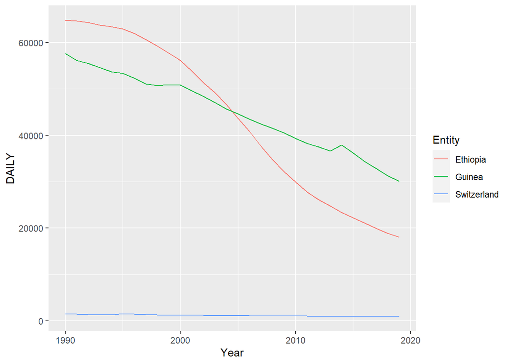

## Attribution

This section was completed by Bapaté BARRY

# Non-Communicable Disease Burden (NCD)

## Table of Estimates for NCD Burden Over Time

| Year | Ethiopia | Guinea | Switzerland |
| --- | --- | --- | --- |
| 1990 | 29898.41 | 26409.09 | 19700.25 |
| 1991 | 29486.17 | 26204.44 | 19573.97 |
| 1992 | 29343.40 | 26126.49 | 19329.69 |
| 1993 | 28937.71 | 25987.81 | 19057.08 |
| 1994 | 28462.61 | 25924.56 | 18870.66 |
| 1995 | 28014.17 | 25824.00 | 18824.10 |
| 1996 | 27395.15 | 25722.26 | 18492.36 |
| 1997 | 26917.13 | 25580.54 | 18303.29 |
| 1998 | 26579.43 | 25655.05 | 18103.51 |
| 1999 | 26154.17 | 25750.12 | 17880.32 |
| 2000 | 25458.76 | 25575.41 | 17717.36 |
| 2001 | 24804.32 | 25572.05 | 17440.60 |
| 2002 | 24315.75 | 25598.80 | 17220.86 |
| 2003 | 23866.15 | 25627.95 | 17020.54 |
| 2004 | 23455.24 | 25872.75 | 16739.51 |
| 2005 | 23124.48 | 25905.90 | 16542.08 |
| 2006 | 22664.14 | 26064.06 | 16385.49 |
| 2007 | 22222.70 | 26099.41 | 16243.25 |
| 2008 | 21799.94 | 25955.25 | 16117.06 |
| 2009 | 21396.34 | 25911.76 | 16046.18 |
| 2010 | 20976.46 | 26022.82 | 15896.66 |
| 2011 | 20750.25 | 25986.43 | 15752.85 |
| 2012 | 20462.53 | 25958.06 | 15672.35 |
| 2013 | 20229.40 | 26052.68 | 15586.22 |
| 2014 | 20138.48 | 26170.02 | 15446.93 |
| 2015 | 19970.90 | 26174.00 | 15340.48 |
| 2016 | 19853.51 | 26030.49 | 15204.87 |
| 2017 | 19809.50 | 25780.08 | 15114.28 |
| 2018 | 19766.89 | 25560.25 | 14967.97 |
| 2019 | 19689.46 | 25112.67 | 14760.75 |

## Plot Showing Trends in NCD Burden Over Time

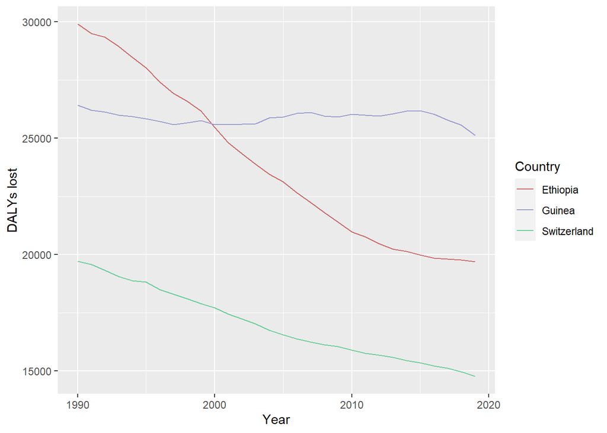

## Summary of NCD Burden Findings

In Ethiopia, the NCD burden (total DALYs lost) decreased significantly since the 90s. In Switzerland, a decrease was also reported but in a smaller scale. In Guinea, the NCD burden is stable since the 90s but a small decrease was identifed in the late 2010’s. To be confirmed with updated data.

## Attribution

This section was completed by Anaïs Léger

The link to the group’s GitHub repository is https://github.com/bapatbarry87-ops/rmc_week_02_workshop_BBAI

# Overall Disease Burden

## Table of Estimates for Overall Disease Burden Over Time

| Year | Ethiopia | Guinea | Switzerland |
| --- | --- | --- | --- |
| 1990 | 107283.27 | 88486.15 | 24919.07 |
| 1991 | 102162.99 | 86824.47 | 24757.26 |
| 1992 | 100404.10 | 86401.49 | 24419.98 |
| 1993 | 99084.13 | 84956.20 | 23997.29 |
| 1994 | 98170.03 | 83974.02 | 23676.55 |
| 1995 | 97185.80 | 83615.38 | 23670.78 |
| 1996 | 95218.18 | 82400.44 | 23103.09 |
| 1997 | 93312.77 | 80945.31 | 22751.97 |
| 1998 | 91492.19 | 80799.80 | 22410.23 |
| 1999 | 92732.75 | 81095.36 | 22109.41 |
| 2000 | 91348.66 | 81532.78 | 21917.00 |
| 2001 | 83895.90 | 79962.21 | 21556.59 |
| 2002 | 80792.69 | 78276.52 | 21198.29 |
| 2003 | 78052.67 | 76967.40 | 20881.83 |
| 2004 | 74958.30 | 75998.33 | 20513.03 |
| 2005 | 71546.76 | 74881.21 | 20211.73 |
| 2006 | 68154.33 | 73981.17 | 19967.94 |
| 2007 | 64350.78 | 73072.75 | 19717.83 |
| 2008 | 60823.98 | 71844.31 | 19501.53 |
| 2009 | 57870.03 | 70918.41 | 19382.94 |
| 2010 | 54961.36 | 69635.84 | 19107.87 |
| 2011 | 52436.59 | 68574.22 | 18887.74 |
| 2012 | 50364.47 | 67730.57 | 18745.92 |
| 2013 | 48614.93 | 67087.79 | 18610.79 |
| 2014 | 47041.12 | 68473.84 | 18404.41 |
| 2015 | 45645.59 | 66737.16 | 18280.04 |
| 2016 | 44442.22 | 64627.63 | 18099.63 |
| 2017 | 43145.65 | 62807.74 | 18009.63 |
| 2018 | 42065.48 | 60991.29 | 17869.21 |
| 2019 | 40990.33 | 59164.53 | 17635.03 |

## Plot Showing Trends in Overall Disease Burden Over Time

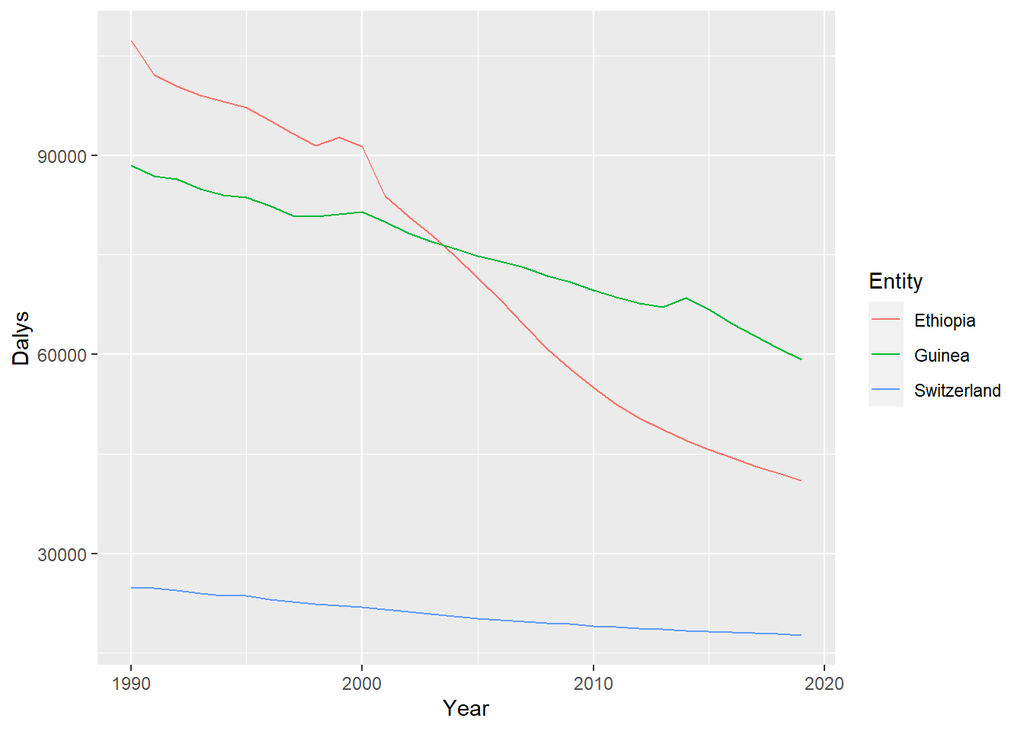

## Attribution

This section was completed by Yabi B.

The link to the group’s GitHub repository is https://github.com/bapatbarry87-ops/rmc_week_02_workshop_BBAI